# HW_5

February 20, 2018

## Preliminary Questions

## Preliminary Question 1

Let \(A\) be the size of the test that corresponds to critical value \(c\).

Consider the case where \(\beta \neq 0\). Then Pr(select true model) = Pr(\(|t| > c\)).

Pr(\(|t| > c\)) = Pr\(\left( \left| \frac {\sqrt{n}(\hat{\beta} - \beta)} {\sqrt{\hat{V}_{\beta}}} + \frac {\sqrt{n}\beta} {\sqrt{\hat{V}_{\beta}}}\right| >c\right)\)

= Pr\(\left[ \left| N \left( \frac {\sqrt{n}\beta} {\sqrt{\hat{V}_{\beta}}}, 1 \right) \right| > c \right]\).

Notice that this probability approaches 1 as \(n \rightarrow \infty\). Thus in a sufficiently large sample we will include \(X_2\) in the model if it should be included.

Next consider the case where \(\beta = 0\).

Then Pr(select true model) = Pr(\(|t| < c\)).

Pr(\(|t| < c\)) = Pr\(\left(\left|\frac{\sqrt{n}(\hat{\beta} - \beta)}{\sqrt{\hat{V}_{\beta}}} + \frac {\sqrt{n}\beta} {\sqrt{\hat{V}_{\beta}}} \right| < c\right)\)

= Pr\(\left(\left|N\left(0, 1 \right) \right| < c\right)\) = \(1-A\).

Notice that this probability is constant as \(n \rightarrow \infty\). Thus if we should exclude \(X_2\) from the model, the probability of selecting the correct model does not approach 1 as \(n \rightarrow \infty\).

We could force this probability to approach 1 by decreasing the size of the test as \(n \rightarrow \infty\), so that \(A_{n}>A_{n+1} \forall n\).

## Preliminary Question 2

Notice that given our results so far, in a sufficiently large sample, we don't have to worry about misspecificiation.

That is, as \(n \rightarrow \infty\), we will include \(X_2\) when we are meant to, although we may also sometimes include \(X_2\) when we don't have to. However, this is not a worry!

The estimator \(\left( \alpha \ \beta \right)' = (X'X)^{-1}(X'Y)\) is consistent for \(\alpha\) in either the case of \(\beta = 0\) or \(\beta \neq 0\) (as long as we don't leave out \(X_2\) when it belongs in the model), so that the post-test estimator of \(\alpha\) is consistent.

## Simulation

## Question 2: Variance

Table 1: Variance of Estimators Given Beta = 0

| beta | names | mean_variance |
| --- | --- | --- |
| 0 | everyday | 0.101 |
| 0 | restricted | 0.100 |
| 0 | unrestricted | 0.140 |

We do indeed see the results shown in class. The variance of the unrestricted estimator is higher than the variance of the restricted estimator. Understandably, the variance of the "everyday" estimator is between the two, though closer to the restricted result.

## Question 3: Bias

Table 2: Bias of Estimators Given Beta Not Zero

| beta | names | mean_bias |
| --- | --- | --- |
| 0.16 | everyday | 0.096 |
| 0.16 | restricted | 0.151 |
| 0.16 | unrestricted | 0.037 |
| 0.24 | everyday | 0.018 |
| 0.24 | restricted | 0.127 |
| 0.24 | unrestricted | -0.041 |
| 0.50 | everyday | -0.278 |
| 0.50 | restricted | 0.051 |
| 0.50 | unrestricted | -0.298 |

## Question 3: Bias

If the covariance of the right hand side variables is zero or the true \(\beta\) parameter value is zero, then there will be no omitted variable bias of the \(\alpha\) parameter. Since we have created data that we know has positive covariance, we will avoid OVB only when \(\beta = 0\).

## Question 4: Alpha in the Confidence Interval

Table 3: Average Times Where Alpha is in the CI

| beta | names | mean_alpha_in_ci |
| --- | --- | --- |
| 0.00 | everyday | 0.936 |
| 0.00 | restricted | 0.951 |
| 0.00 | unrestricted | 0.950 |
| 0.16 | everyday | 0.816 |
| 0.16 | restricted | 0.778 |
| 0.16 | unrestricted | 0.948 |
| 0.24 | everyday | 0.767 |
| 0.24 | restricted | 0.566 |
| 0.24 | unrestricted | 0.951 |
| 0.50 | everyday | 0.887 |
| 0.50 | restricted | 0.129 |
| 0.50 | unrestricted | 0.949 |

## Question 5: Plotted Densities

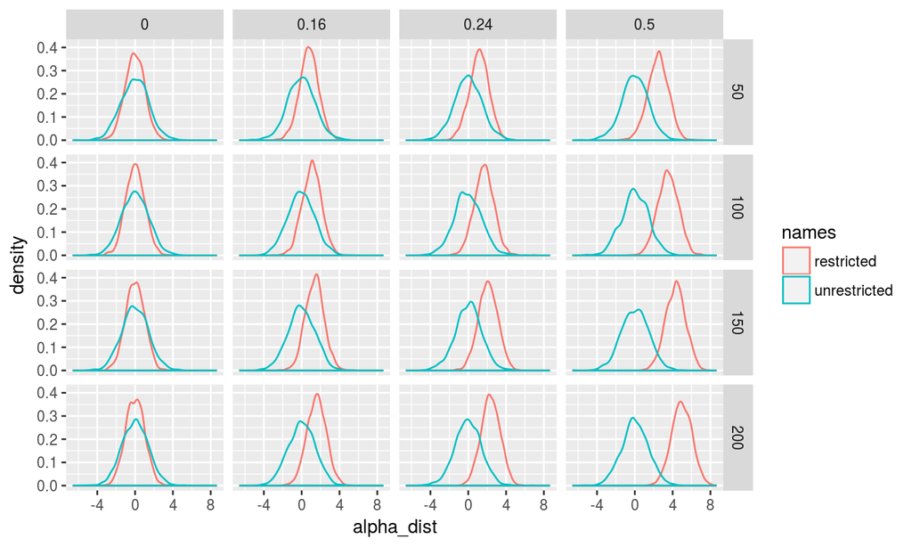

## Question 5: Plotted Densities

We find that in all cases, the distributions are approximately normally distributed, becoming more so in larger samples. When \(\beta = 0\), the restricted model and unrestricted models are centered on zero, but the unrestricted model has a wider variance, as seen previously. When \(\beta\) is not equal to zero, we find that the \(\alpha\) estimator from the restricted model is not consistent.

## Question 6: Plot of Alphas

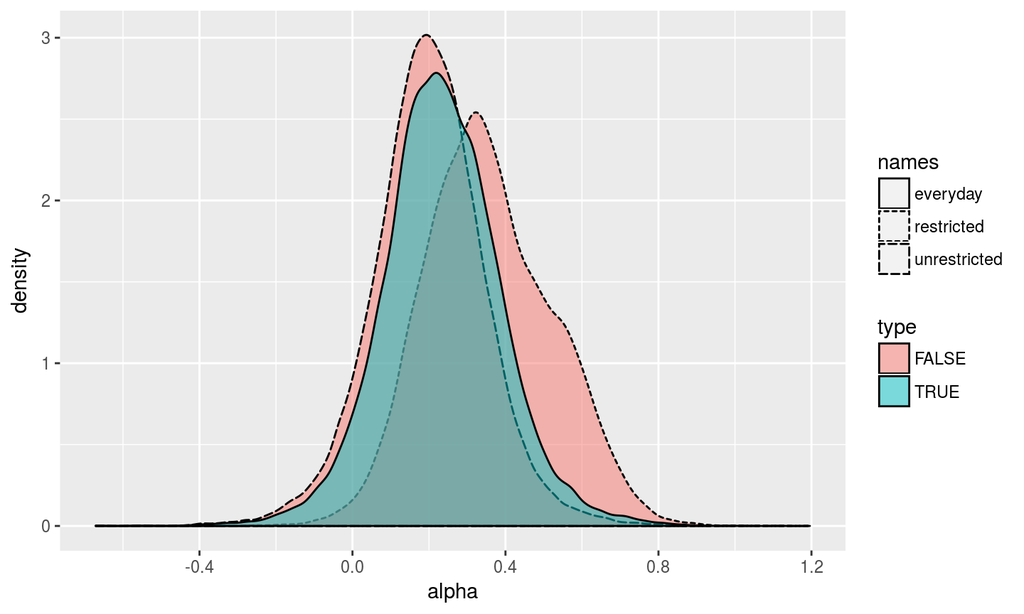